# MDA2025-U6-Losungen

```python
import numpy as np
import matplotlib.pyplot as plt
import matplotlib.cm as cm

import warnings
warnings.filterwarnings(action='ignore')
```

## 6. Übungsblatt SoSe 2025

### Differentialoperatoren

a)

Gegeben sei folgendes Skalarfeld: $\varphi(x,y,z) = xyz + 3x z^3$

Bestimmen Sie am Punkt $P = (1,2,1)$:

- den Gradienten des Skalarfeldes;
- und die Richtungsableitung entlang $\vec{\mathbf{v}} = \left(\begin{array}{r} 1 \\-2 \\2 \end{array}\right)$.

b)

Bestimme die Divergenz der folgenden Vektorfelder:

- $\vec{\mathbf{F}} = \left[\begin{array}{c} -y \\ x \end{array}\right]$
- $\vec{\mathbf{F}} = \left[\begin{array}{c} 2x^3z^2 \\ x^2 - z^2 \\ xyz \end{array}\right]$

c)

Bestimme die Rotation der folgenden Vektorfelder:

- $\vec{\mathbf{F}} = \dfrac{1}{\sqrt{x^2 +y^2}}\left[\begin{array}{c} y \\ -x \end{array}\right]$
- $\vec{\mathbf{F}} = \left[\begin{array}{c} xy - z^2 \\ 2xyz \\ x^2z - y^2z \end{array}\right]$

d)

In welchen Punkten der x-y-Ebene verschwindet die Divergenz des Vektorfeldes $\vec{\mathbf{F}} = \left[\begin{array}{c} xy^2 \\ x^2y - 4y\end{array}\right] ?$

e)

Wie sind die Parameter $u$ und $v$ zu wählen damit $\vec{\mathbf{F}} = \left[\begin{array}{c} 2xz^2 + y^3z \\ uxy^2z \\ 2x^2z + vxy^3\end{array}\right]$ ein wirbelfreies Vektorfeld ist?

#### Lösung

*a)*

- Gradient ist Vektor der partiellen Ableitungen; $\dfrac{\partial \varphi}{\partial x} = yz+3z^3, \; \dfrac{\partial \varphi}{\partial y} = xz, \; \dfrac{\partial \varphi}{\partial z} = xy + 9xz^2$
- am Punkt $P$: $\nabla \varphi = \left[\begin{array}{c} 5 \\ 1 \\ 11 \end{array}\right]$
- Richtungsableitung: Anteil des Gradienten in *Richtung* $\vec{\mathbf{v}}, \; \|\vec{\mathbf{v}}\| = \sqrt{1+4+4} = 3, \; \nabla \varphi^{\scriptscriptstyle \mathrm{T}} \vec{\mathbf{v}} = \left[\begin{array}{r} 5 \\ 1 \\ 11 \end{array}\right]^{\scriptscriptstyle \mathrm{T}} \left[\begin{array}{r} 1 \\-2 \\2 \end{array}\right] = 5-2+22= 25$
- Ergebnis für Richtungsableitung: $\dfrac{\partial \varphi}{\partial \vec{\mathbf{v}}} = \dfrac{\nabla \varphi^{\scriptscriptstyle \mathrm{T}} \vec{\mathbf{v}}}{\|\vec{\mathbf{v}}\|} = \dfrac{25}3$

*b)*

Divergenz: $\nabla^{\scriptscriptstyle \mathrm{T}}\vec{\mathbf{F}} = \dfrac{\partial f_1(x,y,z)}{\partial x} + \dfrac{\partial f_2(x,y,z)}{\partial y} + \dfrac{\partial f_3(x,y,z)}{\partial z}$ für **Vektorfeld** $\vec{\mathbf{F}} = \left[\begin{array}{c} f_1(x,y,z) \\ f_2(x,y,z) \\ f_3(x,y,z) \end{array}\right]$

- $\nabla^{\scriptscriptstyle \mathrm{T}}\left[\begin{array}{c} -y \\ x \end{array}\right] = 0 + 0 = 0$, d.h. das Vektorfeld ist *quellenfrei*
- $\nabla^{\scriptscriptstyle \mathrm{T}}\left[\begin{array}{c} 2x^3z^2 \\ x^2 - z^2 \\ xyz \end{array}\right] = 6x^2z^2 + 0 + xy = 6x^2z^2 + xy$

*c)*

Rotation: $\nabla \times\vec{\mathbf{F}} = \left[\begin{array}{c} \dfrac{\partial f_3(x,y,z)}{\partial y} - \dfrac{\partial f_2(x,y,z)}{\partial z} \\ \dfrac{\partial f_1(x,y,z)}{\partial z} - \dfrac{\partial f_3(x,y,z)}{\partial x} \\ \dfrac{\partial f_2(x,y,z)}{\partial x} - \dfrac{\partial f_1(x,y,z)}{\partial y} \end{array}\right]$ für **Vektorfeld** $\vec{\mathbf{F}} = \left[\begin{array}{c} f_1(x,y,z) \\ f_2(x,y,z) \\ f_3(x,y,z) \end{array}\right]$

- $ \nabla \times \left(\dfrac{1}{\sqrt{x^2 +y^2}}\left[\begin{array}{c} y \\ -x \\ 0\end{array}\right]\right) = \left[\begin{array}{c} 0-0 \\ 0-0 \\ -(x^2 +y^2)^{-\frac{1}{2}} + x^2(x^2 +y^2)^{-\frac{3}{2}} - (x^2 +y^2)^{-\frac{1}{2}} + y^2(x^2 +y^2)^{-\frac{3}{2}}\end{array}\right] = \left[\begin{array}{c} 0 \\ 0 \\ -\dfrac{1}{\sqrt{x^2 + y^2}}\end{array}\right]$
- $\nabla^{\scriptscriptstyle \mathrm{T}} \left[\begin{array}{c} xy - z^2 \\ 2xyz \\ x^2z - y^2z \end{array}\right] = \left[\begin{array}{c} -2yz - 2xy \\ -2z - 2xz \\ 2yz - x \end{array}\right] = \left[\begin{array}{c} -2y(z + x) \\ -2z(1 + x) \\ 2yz - x \end{array}\right]$

*d)*

- Divergenz: $\nabla^{\scriptscriptstyle \mathrm{T}}\vec{\mathbf{F}} = \left[\begin{array}{c} \dfrac{\partial}{\partial x} \\\dfrac{\partial}{\partial y} \end{array}\right]^{\scriptscriptstyle \mathrm{T}}\left[\begin{array}{c} xy^2 \\ x^2y - 4y\end{array}\right] = \dfrac{\partial}{\partial x}\left( xy^2\right) + \dfrac{\partial}{\partial y}\left( x^2y - 4y\right) = y^2 + x^2 - 4 \equiv 0$
- Umstellen der Gleichung: $x^2 + y^2 = 4$ $\hookrightarrow$ Mittelpunktskreis mit Radius 2

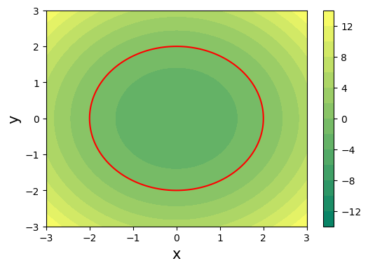

```python
x = np.linspace(-3,3,101)
y = np.linspace(-3,3,101)
xx,yy = np.meshgrid(x,y)
f = xx**2 + yy**2 - 4

fig = plt.figure(figsize=(6,4))
ax = fig.add_subplot(111)
clb=ax.contourf(xx,yy,f, np.arange(-14,15,2), cmap = cm.summer)
ax.contour(xx,yy,f,[0], colors='red')
ax.set_xlabel('x',fontsize=15)
ax.set_ylabel('y',fontsize=15)
fig.colorbar(clb,ax=ax)
plt.show()
```

*e)*

- Rotation: $\nabla \times\vec{\mathbf{F}} = \left[\begin{array}{c} \dfrac{\partial}{\partial x} \\\dfrac{\partial}{\partial y} \\ \dfrac{\partial}{\partial z} \end{array}\right] \times \left[\begin{array}{c} 2xz^2 + y^3z \\ uxy^2z \\ 2x^2z + vxy^3\end{array}\right] = \left[\begin{array}{c} \dfrac{\partial \left(2x^2z + vxy^3\right)}{\partial y} - \dfrac{\partial \left(uxy^2z\right)}{\partial z} \\ \dfrac{\partial \left(2xz^2 + y^3z\right)}{\partial z} - \dfrac{\partial \left(2x^2z + vxy^3\right)}{\partial x} \\ \dfrac{\partial \left(uxy^2z\right)}{\partial x} - \dfrac{\partial \left(2xz^2 + y^3z\right)}{\partial y} \end{array}\right] = \left[\begin{array}{c} 3vxy^2 - uxy^2 \\ 4xz+y^3 - (4xz+vy^3) \\ uy^2z - 3y^2z \end{array}\right] \equiv \left[\begin{array}{c} 0 \\ 0 \\ 0 \end{array}\right]$
- Betrachtung der einzelnen Komponenten: $ y^3 - vy^3 = 0 \hookrightarrow v=1, \; uy^2z - 3y^2z = 0 \hookrightarrow u=3, \; 3\cdot 1 \cdot xy^2 - 3 \cdot xy^2 = 0$

### Anwendung Differentialoperatoren

Das Geschwindigkeitsfeld einer Flüssigkeit lässt sich durch folgende Gleichung $$\vec{\mathbf{v}} = \left[\begin{array}{c} ax \\ -ay \end{array} \right]$$ beschreiben. Hierbei gilt $a > 0$, $-\infty < x < \infty$ und $y \ge 0$.

*a)* Überprüfe, ob es sich um ein quellen- und rotationsfreies Vektorfeld handelt.

*b)* Bestimme das zugehörige Skalarfeld $\phi(x,y)$ welches aus dem Zusammenhang $\nabla \phi(x,y) = \vec{\mathbf{v}}$. Es gilt dabei $\phi(0,0) = 0$. Bestimme zusätzlich den Funktionstyp der entsprechenden Höhenlinien des Skalarfeldes.

*c*) Bestimme die Gleichungen der sogenannten Stromlinien, welche sich aus der Gleichung $ \vec{\mathbf{v}} \times \left[\begin{array}{c} \mathrm{d}x \\ \mathrm{d}y \\ 0 \end{array} \right] = \vec{\mathbf{0}}$ bestimmen lassen.

#### Lösung

*a)*

$\mathrm{div} \vec{\mathbf{v}} = a -a = 0$ , daher ist das Feld *quellenfrei*

$\mathrm{rot} \vec{\mathbf{v}} = \vec{\mathbf{0}}$, da alle Ableitungen verschwinden und somit ist das Feld *rotationsfrei*

Daher bezeichnet man das Geschwindigkeitsfeld als **Potentialströmung**.

*b)*

$\nabla\phi(x,y) = \left[\begin{array}{c} \dfrac{\mathrm{d} \phi}{\mathrm{d}x} \\ \dfrac{\mathrm{d} \phi}{\mathrm{d}y} \end{array} \right] = \left[\begin{array}{c} ax \\ -ay \end{array} \right] $

Es ergeben sich 2 Gleichungen $\dfrac{\mathrm{d} \phi}{\mathrm{d}x} = ax$ und $\dfrac{\mathrm{d} \phi}{\mathrm{d}y} = -ay$.

Integration der 1. Gleichung liefert

$\phi = \int ax \mathrm{d}x = \dfrac{1}{2} ax^2 + C(y)$

Ableitung dieser Gleichung nach $y$ führt auf

$\dfrac{\mathrm{d} \phi}{\mathrm{d}y} = C^\prime = -ay$

Integration nach y liefert

$C = -\dfrac{1}{2} ay^2 + D$

Zusammenführung der Gleichung für $\phi$ und $C$ führt auf

$\phi = \dfrac{1}{2} ax^2 - \dfrac{1}{2} ay^2 + D$ mit $D$ als Konstante

Einsetzen der Randbedingung führt auf

$\phi(0,0) = \dfrac{1}{2} a0^2 - \dfrac{1}{2} a0^2 + D = 0$ und somit auf $D=0$ bzw. auf $\phi = \dfrac{1}{2} ax^2 - \dfrac{1}{2} ay^2$.

Die Funktion $\phi$ wird als **Potential** des Geschwindigkeitsfeldes bezeichnet.

Die Höhenlinien ergeben sich aus

$\phi = C = \dfrac{1}{2} ax^2 - \dfrac{1}{2} ay^2$ was sich darstellen lässt als $x^2 - y^2 = C = \mathrm{konstant}$. Der Funktionstyp ist daher eine Hyperbel mit $y \ge 0$.

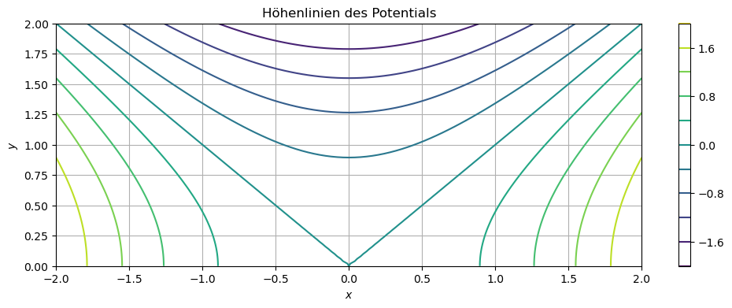

```python
a = 1
x = np.linspace(-2,2,101)
y = np.linspace(0,2,101)
xx,yy = np.meshgrid(x,y)
f = 1/2*a*(xx**2 - yy**2)

fig,ax = plt.subplots(1,1,figsize=(12,4))
clb = ax.contour(xx,yy,f,10)
ax.set_xlabel('$x$')
ax.set_ylabel('$y$')
ax.set_title('Höhenlinien des Potentials')
ax.grid()
fig.colorbar(clb, ax=ax)
plt.show()
```

*c)*

aus $ \vec{\mathbf{v}} \times \left[\begin{array}{c} \mathrm{d}x \\ \mathrm{d}y \\ 0 \end{array} \right]$ ergibt sich

$ax \mathrm{d}y + ay \mathrm{d}x = 0$

Mittels *Trennen der Variablen* ergibt sich

$\dfrac{1}{y}\mathrm{d}y = -\dfrac{1}{x}\mathrm{d}x$ und mittels Integration ergibt sich $\ln(|y|) = -\ln(|x|) + \ln(|C|) = \ln\left(\dfrac{C}{|x|}\right)$ (es bietet sich an die Konstante ebenfalls als logarithmische Funktion zu schreiben).

Umformen nach $y$ ergibt

$y = \dfrac{C}{|x|}$ mit $C,y > 0$

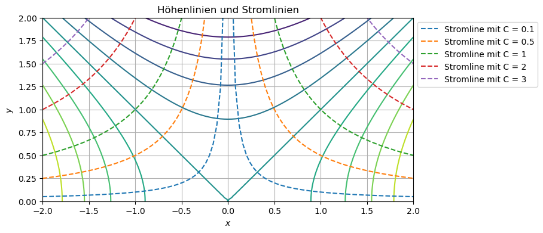

```python
a = 1
x = np.linspace(-2,2,101)
y = np.linspace(0,2,101)
xx,yy = np.meshgrid(x,y)
f = 1/2*a*(xx**2 - yy**2)

fig,ax = plt.subplots(1,1,figsize=(8,4))
clb = ax.contour(xx,yy,f,10)
for c in [0.1, 0.5, 1,2,3]:
    s = c/np.abs(x)
    ax.plot(x, s, linestyle='--', label='Stromline mit C = {}'.format(c))
ax.set_xlabel('$x$')
ax.set_ylabel('$y$')
ax.set_title('Höhenlinien und Stromlinien')
ax.grid()
#fig.colorbar(clb, ax=ax)
ax.set_ylim([0,2])
ax.legend(bbox_to_anchor=[1,1])
plt.show()
```